# Apartment Data Toronto

Trevor Mason

May 20, 2021

# 1 Introduction

The Apartment Building Standard (ABS) program is based on a new bylaw Chapter 354, which defines formal criteria to identify all rental apartment buildings in the city with 3 or more storeys and 10 or more units. The ABS program is part of RentSafeTO which is a multi-residential inspection program that establishes standards on how building owners operate their building(s) and communicate with their tenants, in addition to establishing a schedule for continuous building evaluation, audit and enforcement of these standards.

This dataset contains building information for the buildings that are registered in the ABS program. This information was collected from building owners/managers during the initial registration process, and is updated on an annual basis as part of the registration renewal process. (https://open.toronto.ca/dataset/apartment-building-registration/)

I would like to know what has the greatest impact on whether pets are allowed in an apartment building in Toronto. Specifically, whether it is affected by the following:

- having balconies (`BALCONIES`),
- the number of confirmed storeys (`CONFIRMED_STOREYS`),
- the confirmed number of units (`CONFIRMED_UNITS`),
- having exterior fire escape (`EXTERIOR_FIRE_ESCAPE`),
- if there are garbage chutes (`GARBAGE_CHUTES`),
- the number of elevators (`NO_OF_ELEVATORS`),
- the building postal code (`PCODE`),
- the company that manages the property (`PROP_MANAGEMENT_COMPANY_NAME`),
- the property type (`PROPERTY_TYPE`),
- the ward in which the building is located (`WARD`),
- type of windows (`WINDOW_TYPE`), and
- the year the building was built (`YEAR_BUILT`).

# 2 Analysis

## 2.1 Plot comparisons

### 2.1.1 Balconies

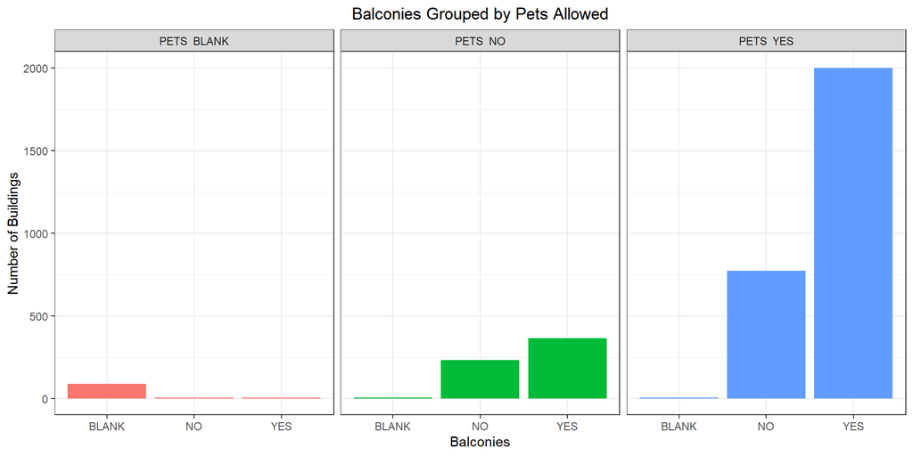

### 2.1.2 Confirmed Storeys

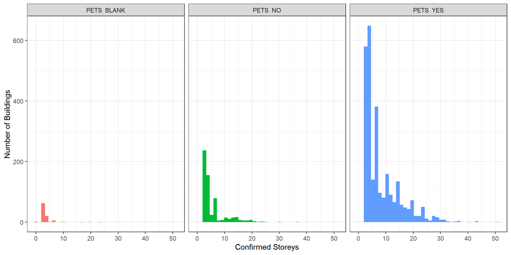

### 2.1.3 Confirmed Units

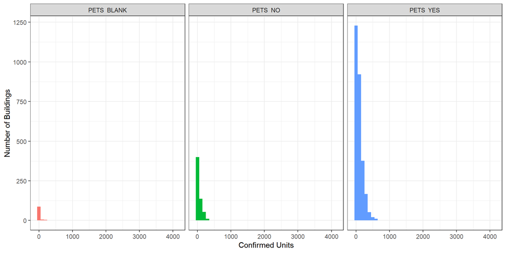

### 2.1.4 Exterior Fire Escape

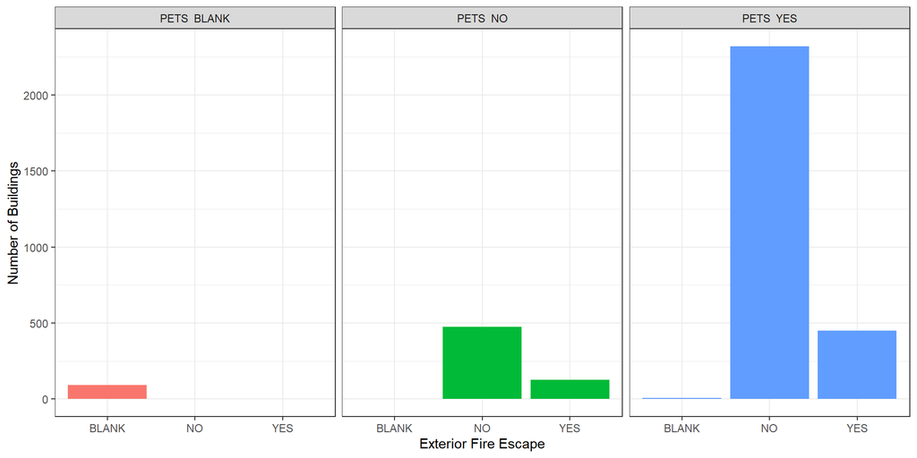

### 2.1.5 Garbage Chutes

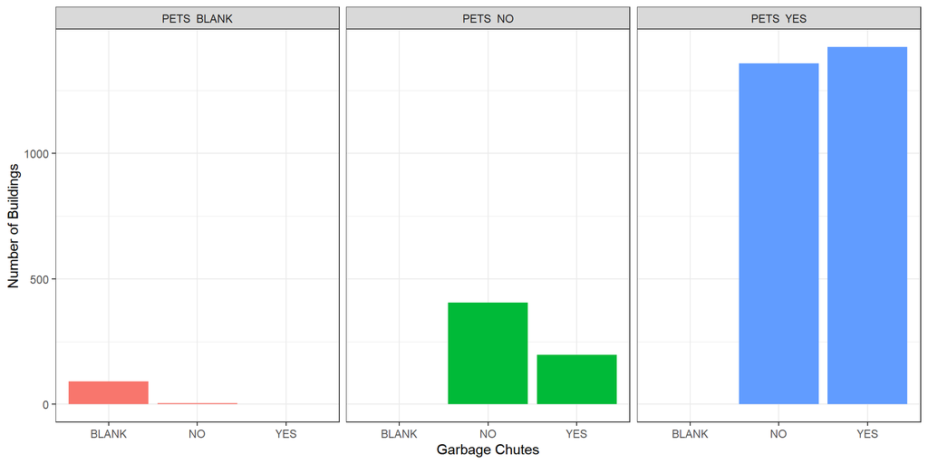

### 2.1.6 Number of Elevators

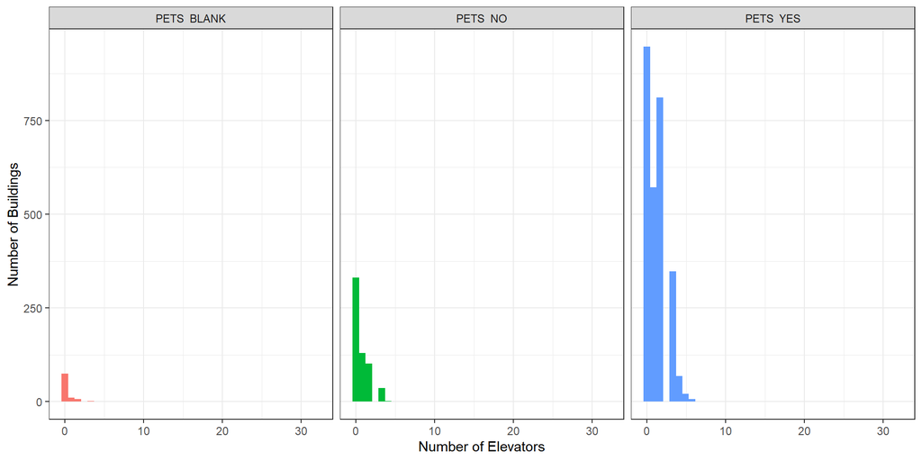

### 2.1.7 Postal Code

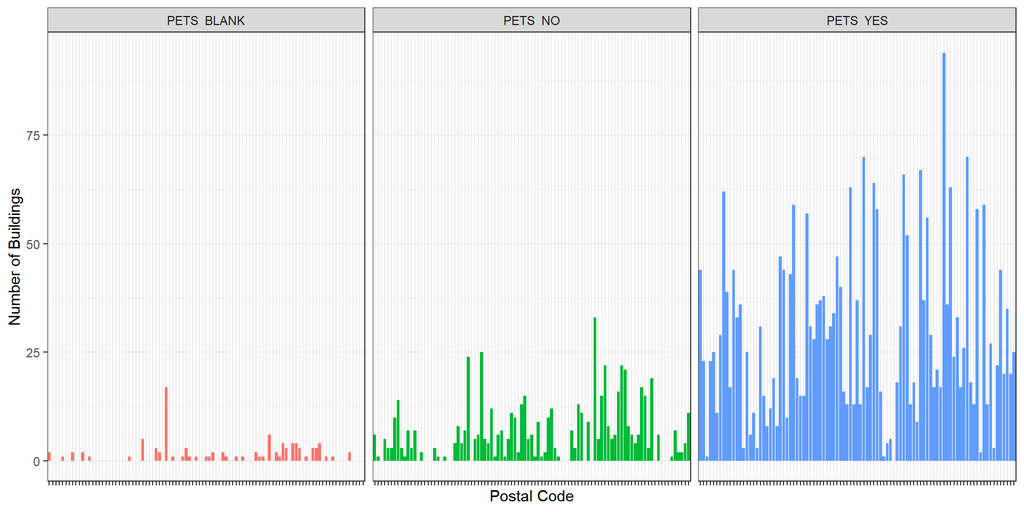

### 2.1.8 Property Management Company

[figure not shown]

### 2.1.9 Property Type

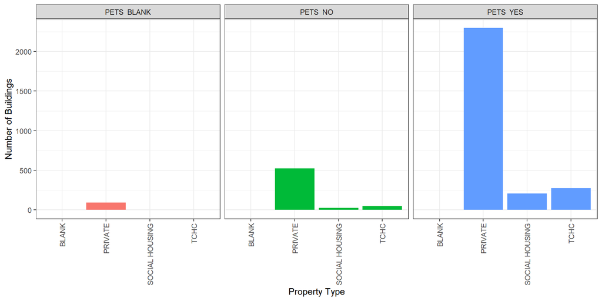

### 2.1.10 Ward

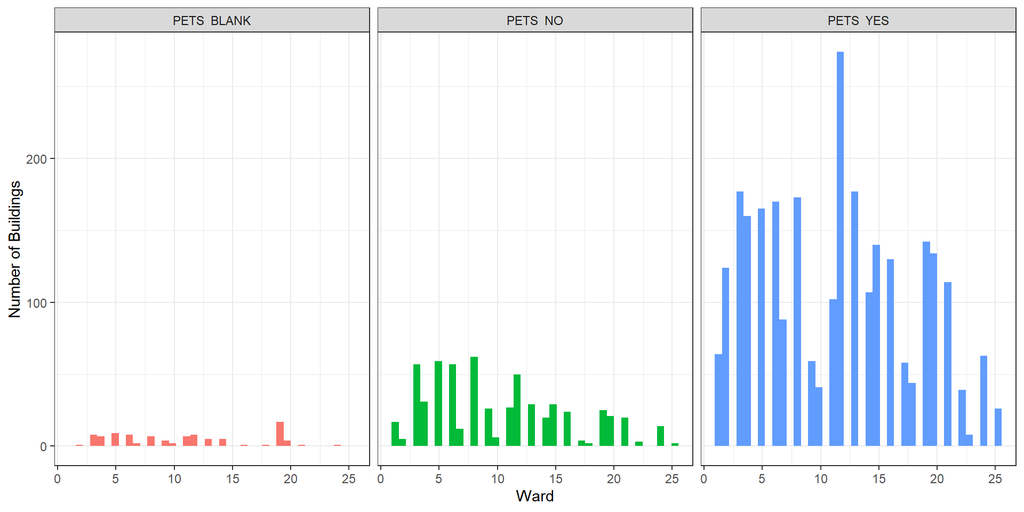

### 2.1.11 Window Type

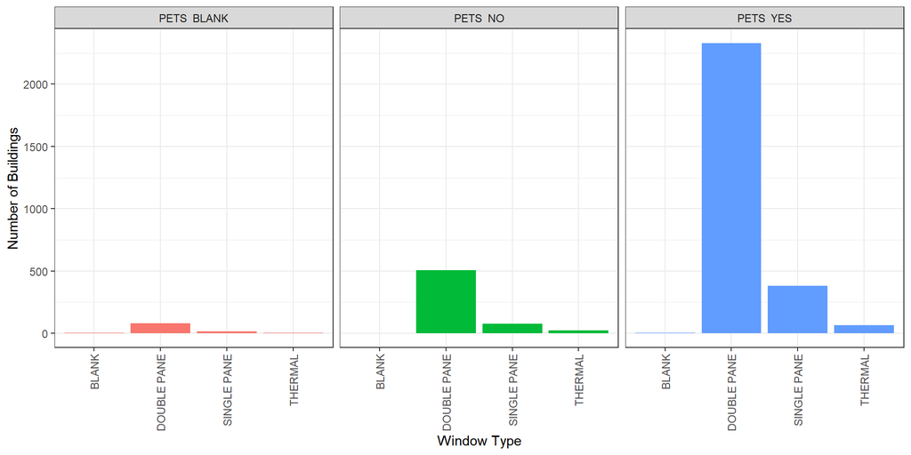

### 2.1.12 Year Built

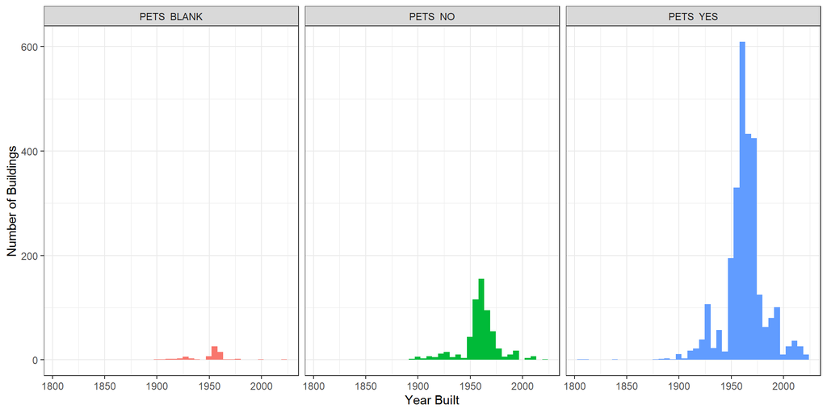